[OHI British Columbia](http://www.ohibc.org/) | [OHI Science](http://ohi-science.org) | [Citation policy](https://github.com/OHI-Science/ohiprep/releases)

# Set up CHI mean stressor rasters to loiczid

Compiled on Thu Mar 15 21:01:55 2018 by ohara

```r
knitr::opts_chunk$set(fig.width = 6, fig.height = 4, fig.path = 'Figs/',
                      echo = TRUE, message = FALSE, warning = FALSE)

library(raster)
library(sf)
library(fasterize)

source('~/github/src/R/common.R')  ###
  ### includes library(tidyverse); library(stringr); dir_M points to ohi directory

dir_git <- '~/github/spp_health_dists'

### goal specific folders and info
dir_setup   <- file.path(dir_git, 'data_setup')
dir_spatial <- file.path(dir_git, 'spatial')
dir_anx     <- file.path(dir_M, 'git-annex')
dir_o_anx   <- file.path(dir_O, 'git-annex/spp_health_dists')
# ### provenance tracking
# library(provRmd); prov_setup()

### support scripts
source('~/github/src/R/rast_tools.R')
  ### raster plotting and analyzing scripts

### bring in ocean raster (all 1 or NA values)
ocean_base <- raster(file.path(dir_M, 'model/GL-NCEAS-Halpern2008/tmp/ocean.tif'))
```

# 1 Summary

Using the LOICZID raster and rasters of CHI stressors layers, create mean and var stressors for each LOICZID cell

# 2 Data Sources

# 3 Methods

## 3.1 Identify stressors layers

```r
dir_prs <- file.path(dir_M, 'marine_threats/impact_layers_2013_redo',
                     'global_impact_model_2013',
                     'normalized_by_one_time_period',
                     'averaged_by_num_ecosystems')
### cumulative impacts data (all 2013 pressures combined)
ci <- raster(file.path(dir_prs, 'all_layers/global_cumul_impact_2013_all_layers.tif'))
# ci
# plot(ci)

### individual pressures (2013)
### stressor data combined with the pressure X habitat vulnerability matrix and habitat raster layers
pressure_example <- raster(file.path(dir_prs, 'by_threat/shipping_combo.tif'))
# pressure_example
# plot(pressure_example)

prs_layers <- list.files(file.path(dir_prs, 'by_threat'), pattern = '.tif$')
#  [1] "artisanal_fishing_combo.tif"             "demersal_destructive_fishing_combo.tif"
#  [3] "demersal_nondest_high_bycatch_combo.tif" "demersal_nondest_low_bycatch_combo.tif"
#  [5] "inorganic_combo.tif"                     "invasives_combo.tif"
#  [7] "night_lights_combo.tif"                  "ocean_acidification_combo.tif"
#  [9] "ocean_pollution_combo.tif"               "oil_rigs_combo.tif"
# [11] "pelagic_high_bycatch_combo.tif"          "pelagic_low_bycatch_combo.tif"
# [13] "plumes_fert_combo.tif"                   "plumes_pest_combo.tif"
# [15] "population_combo.tif"                    "shipping_combo.tif"
# [17] "slr_combo.tif"                           "sst_combo.tif"
# [19] "uv_combo.tif"

### stressors (data rescaled from 0-1 using max value)
dir_stressor_orig <- file.path(dir_M, 'marine_threats/impact_layers_2013_redo',
                        'impact_layers/final_impact_layers/threats_2013_final',
                        'normalized_by_one_time_period')

# stressor_layers_orig <- list.files(dir_stressor_orig, pattern = '.tif$')
#  [1] "artisanal_fishing.tif"             "demersal_destructive_fishing.tif"
#  [3] "demersal_nondest_high_bycatch.tif" "demersal_nondest_low_bycatch.tif"
#  [5] "inorganic.tif"                     "invasives.tif"
#  [7] "night_lights.tif"                  "ocean_acidification.tif"
#  [9] "ocean_pollution.tif"               "oil_rigs.tif"
# [11] "pelagic_high_bycatch.tif"          "pelagic_low_bycatch.tif"
# [13] "plumes_fert.tif"                   "plumes_pest.tif"
# [15] "population.tif"                    "shipping.tif"
# [17] "slr.tif"                           "sst.tif"
# [19] "uv.tif"
# stressor <- raster(file.path(dir_stressor_orig, 'shipping.tif'))
```

## 3.2 Choose layers and inspect distributions

For the purposes of this investigation, we will use the stressors which include stress but exclude habitat vulnerability.

To aggregate the 934 m cells to half-degree cells, we will use zonal stats to match LOICZID to cells, and take a mean.

- Since many (most? all?) of the layers are probably heavily right-skewed, should we use a log-normal mean to get a better sense of the central tendency?
- Note that values within each cell may not be log-normally distributed…
- Note that we’ll have to remove zeros. We can (maybe?) add zeros back in, doing an area-weighted simple average of the log-normal mean (for non-zero areas) and zero (for zero areas).
- For simplicity, in order to get to the spatial analysis, I will begin with a simple mean of values within each LOICZID zone.

First inspect each layer to get an idea of distributions:

- mask to ocean base raster to exclude land cells and mollweide corners
- take a random sample of values to simplify the distribution plotting
- some layers should be clipped to coastal areas (e.g. sea level rise) but we’ll gloss over this for now…
  - for such stressors, should zero values be OK? i.e. will a zero for that layer in the open ocean create the same effect as an NA for that layer?

```r
### this chunk is necessary to ensure extents and resolution of stressor
### layers match each other and the ocean_base raster.

# stressor_layers_orig <- list.files(dir_stressor_orig,
#                          pattern = '.tif$',
#                          full.names = TRUE)

dir_stressor_new <- file.path(dir_M, 'git-annex/impact_acceleration/stressors/')
strs_new <- list.files(dir_stressor_new, recursive = TRUE, full.names = TRUE)
strs_new <- strs_new[str_detect(strs_new, 'final') & str_detect(strs_new, 'sst_2012|_2016')]


dir_stressor_anx <- file.path(dir_o_anx, 'stressors_fullext')

for(lyr in strs_new) { ### lyr <- strs_new[1]
# for(lyr in stressor_layers_orig) { ### lyr <- stressor_layers_orig[10]

  rast_full_ext_file <- file.path(dir_stressor_anx, basename(lyr) %>%
                                    str_replace('_rescaled_mol', ''))
  if(!file.exists(rast_full_ext_file)) {
    lyr_rast <- raster(lyr)
    if(!isTRUE(all.equal(extent(ocean_base), extent(lyr_rast)))) {
      message('Extending ', lyr, ' and saving to:\n  ', rast_full_ext_file)
      # lyr_rast <- lyr_rast %>%
      #   extend(ocean_base,
      #          progress = 'text',
      #          filename = rast_full_ext_file)
      lyr_rast1 <- lyr_rast %>% ### for ocean_pollution and invasives, since extend didn't work...
        projectRaster(ocean_base, method = 'ngb',
               progress = 'text',
               filename = rast_full_ext_file, overwrite = TRUE)
    } else {
      message('Copying ', lyr, ' to:\n  ', rast_full_ext_file)
      file.copy(lyr, rast_full_ext_file)
    }
  } else {
    message('Full-extent stressor raster file exists: \n  ', rast_full_ext_file)
  }

}
```

```r
stressor_layers <- list.files(dir_stressor_anx,
                         pattern = '.tif$',
                         full.names = TRUE)

for (layer in stressor_layers) { ### layer <- stressor_layers[1]

  lyr_rast_raw <- raster(layer)

  lyr_distr_file <- sprintf('stressor_distr_plots/%s_distr.png', names(lyr_rast_raw))

  if(!file.exists(lyr_distr_file)) {
    message('generating distr plot for: ', lyr_distr_file)
    lyr_rast <- mask(lyr_rast_raw, ocean_base)
    lyr_sample <- base::sample(values(lyr_rast), 10000000)
    lyr_sample_narm <- lyr_sample[!is.na(lyr_sample)]
    lyr_zeros_removed <- lyr_sample_narm[lyr_sample_narm > 0]
    lyr_sample_df <- data.frame(val = lyr_zeros_removed)

    plot_name <- sprintf('%s (%.4fpct of vals = 0, removed)',
                         names(lyr_rast), 100 * (length(lyr_sample_narm) -
                                                   length(lyr_zeros_removed)) / length(lyr_sample_narm))
    lyr_dist <- ggplot(lyr_sample_df, aes(x = val)) +
      ggtheme_plot() +
      geom_density() +
      labs(title = plot_name,
           x = 'rescaled stressor')

    ggsave(lyr_distr_file, plot = lyr_dist)

  } else {
    message('layer distr plot already exists: ', lyr_distr_file)
  }
}
```

### 3.2.1 Fishing layers

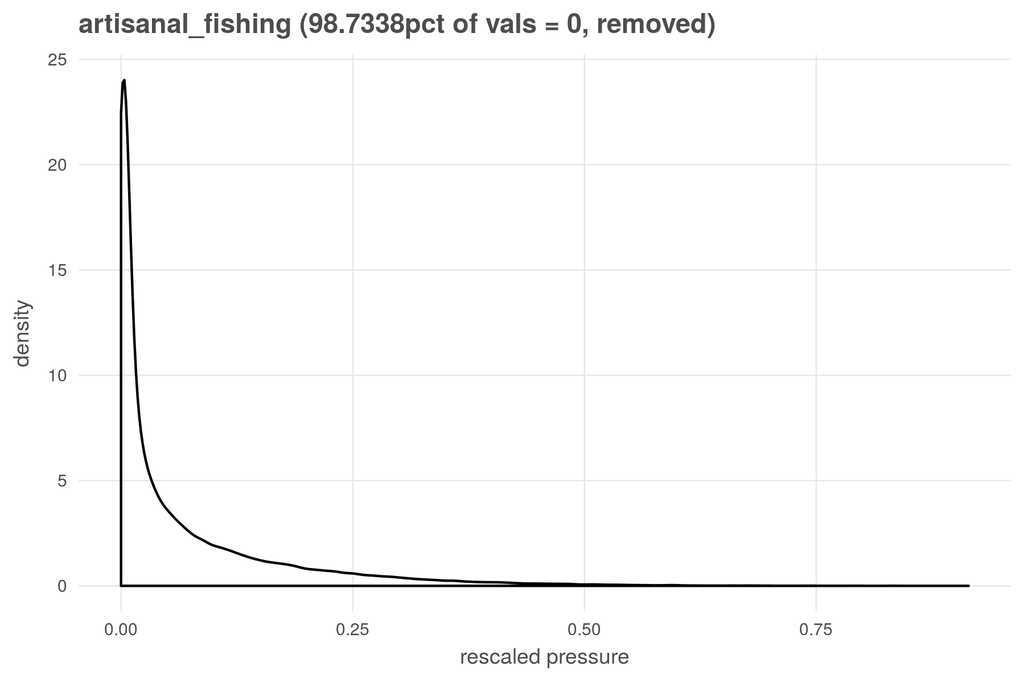

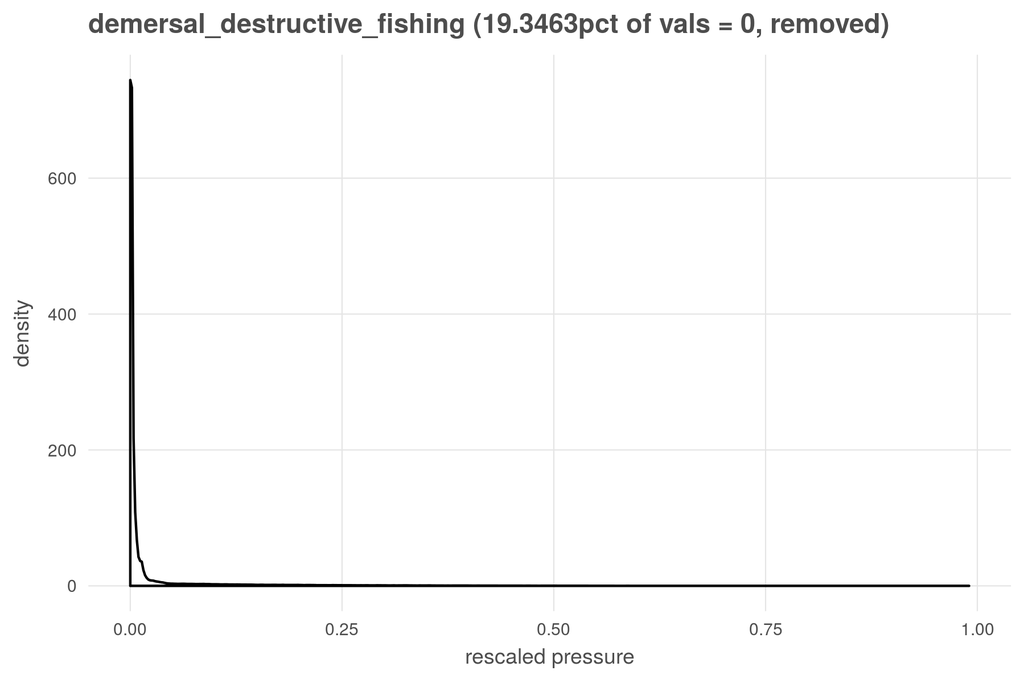

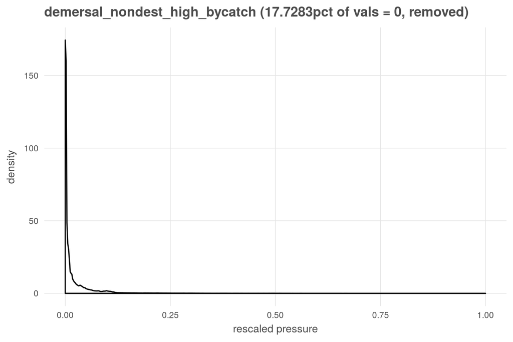

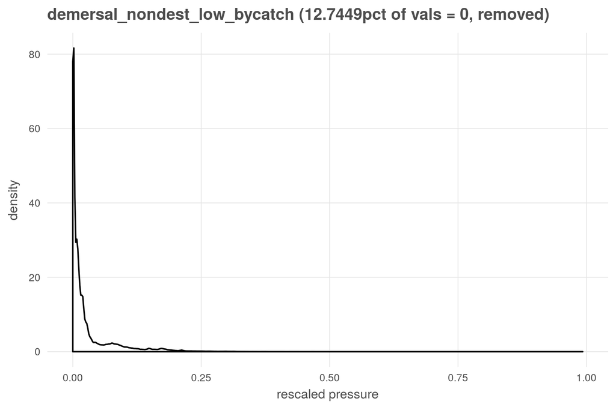

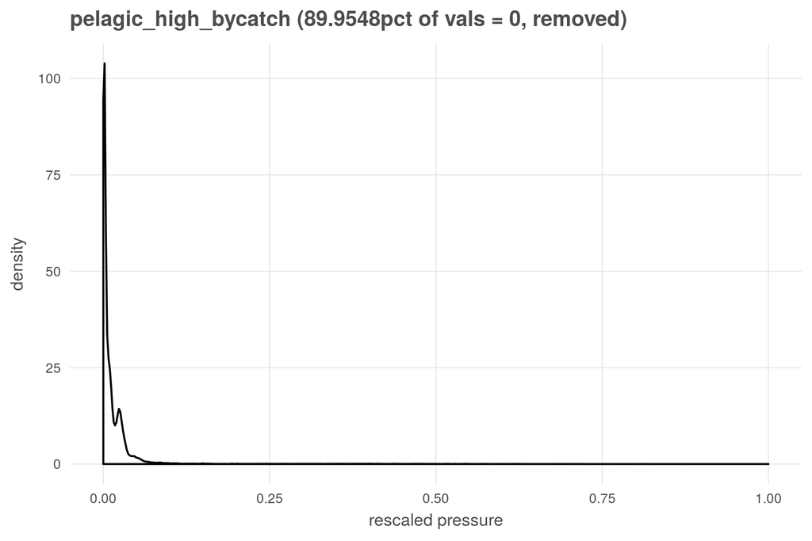

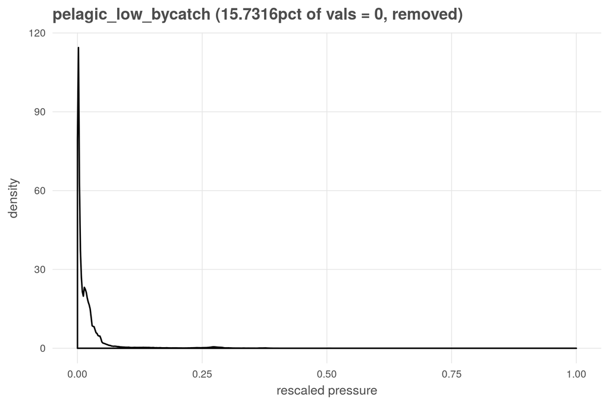

### 3.2.2 Climate layers

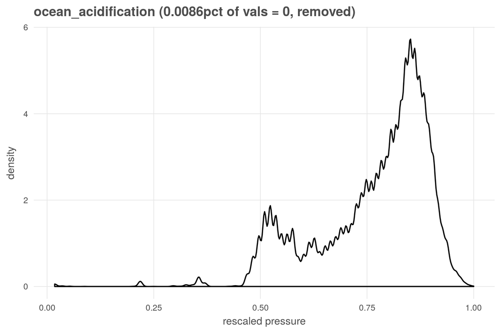

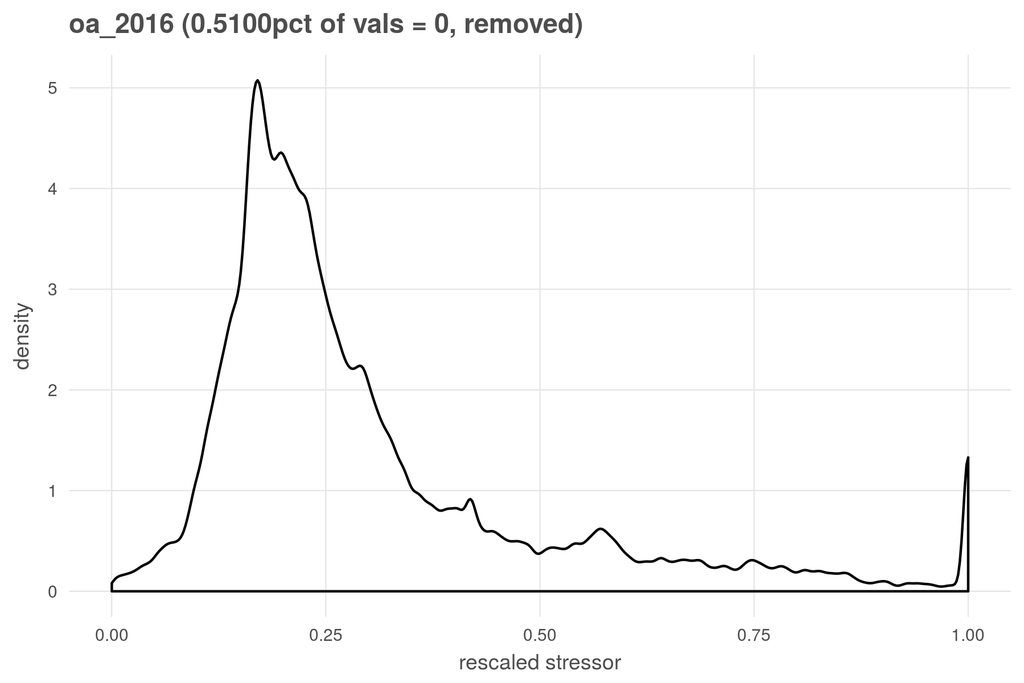

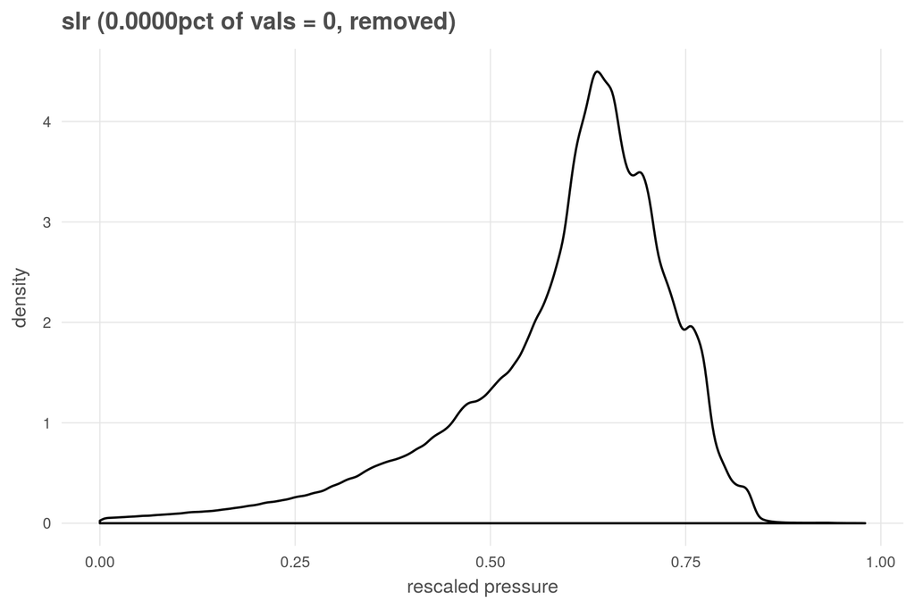

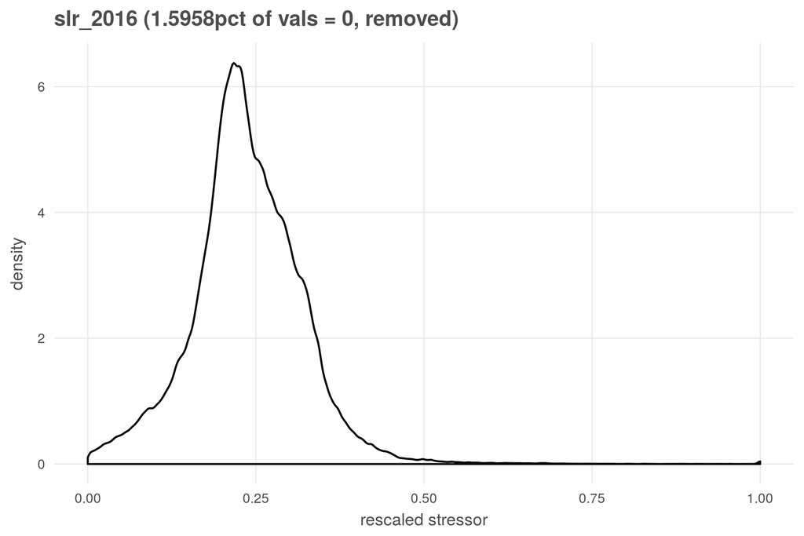

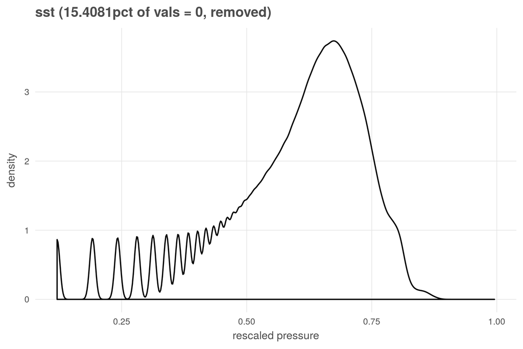

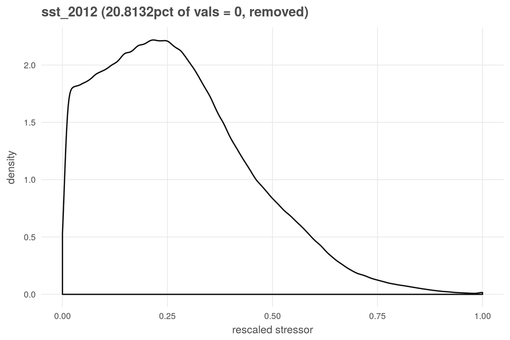

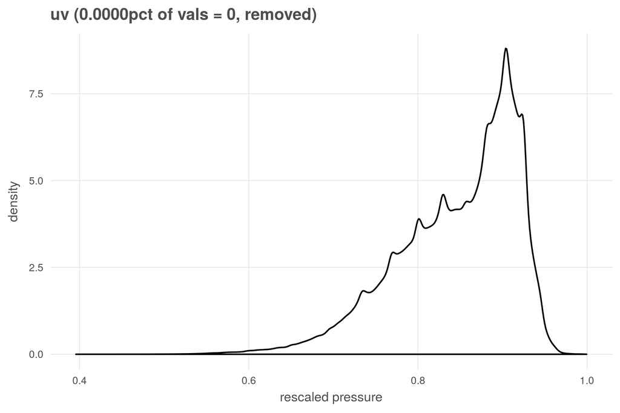

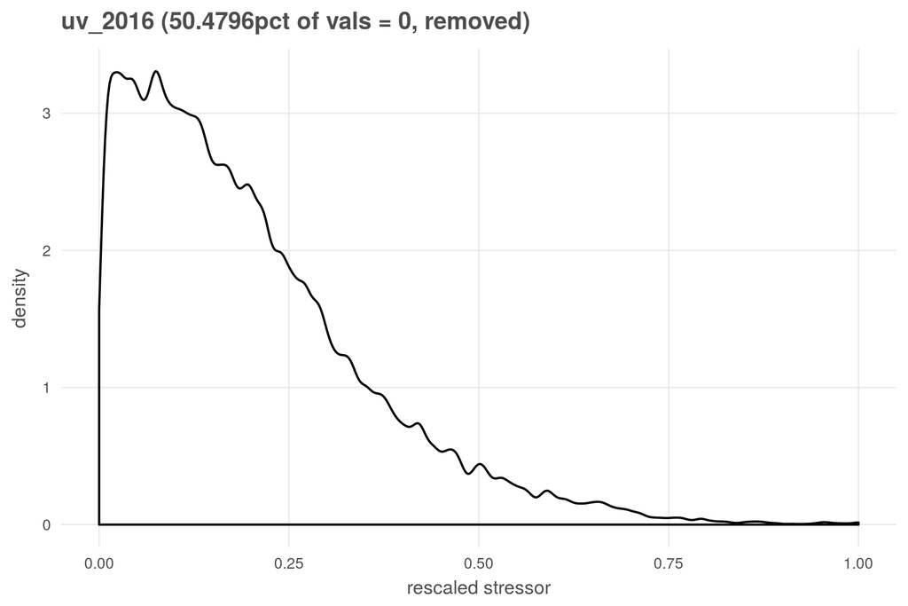

### 3.2.3 Pollution layers

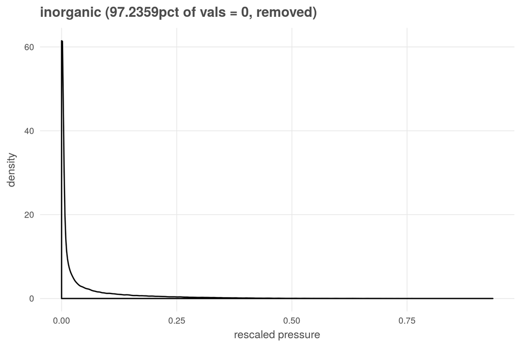

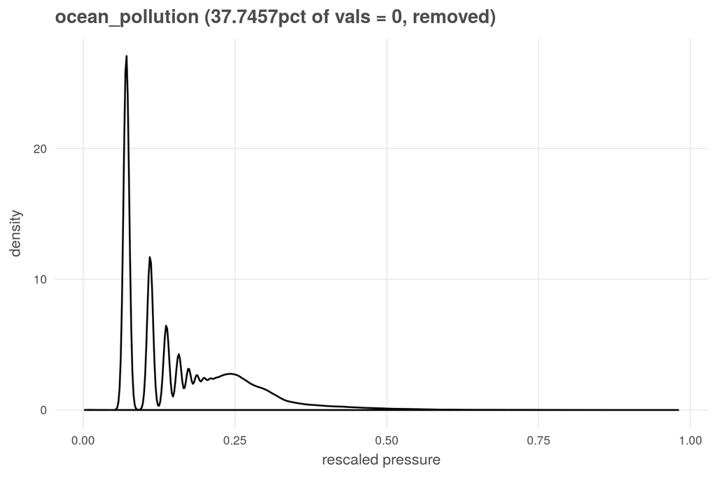

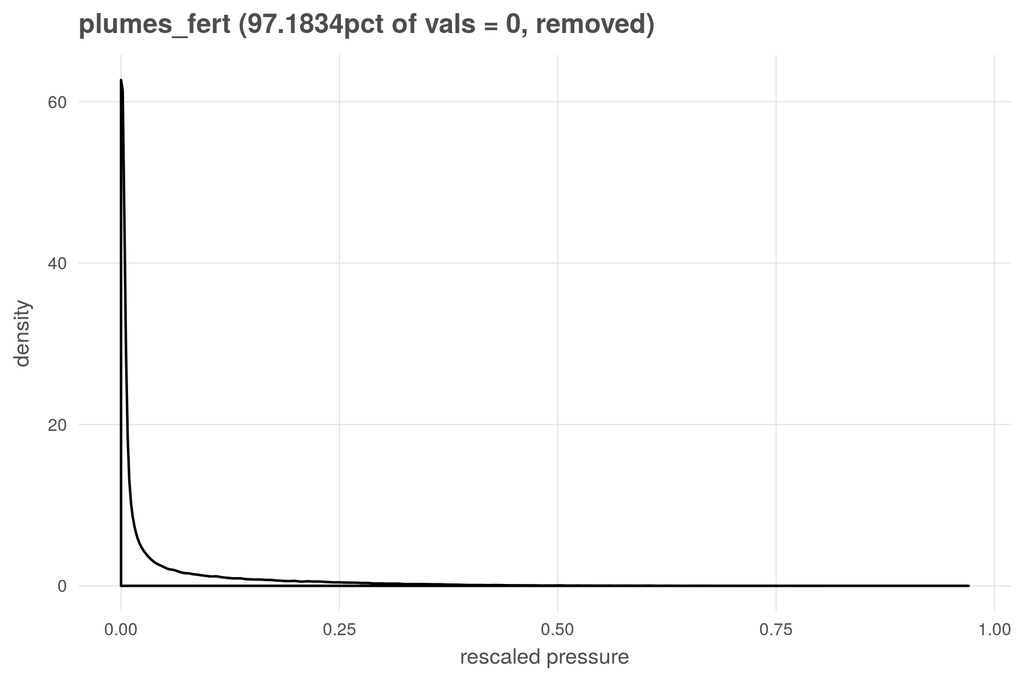

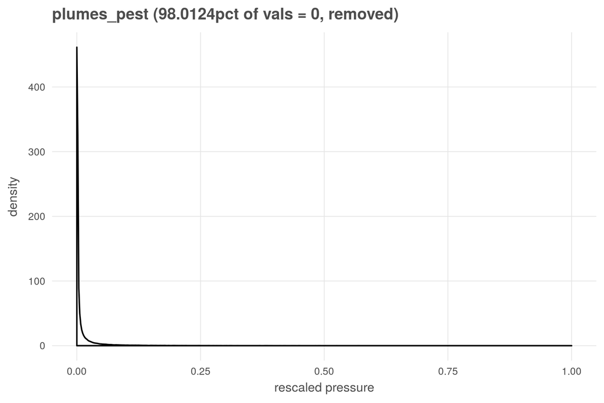

### 3.2.4 Other human impacts

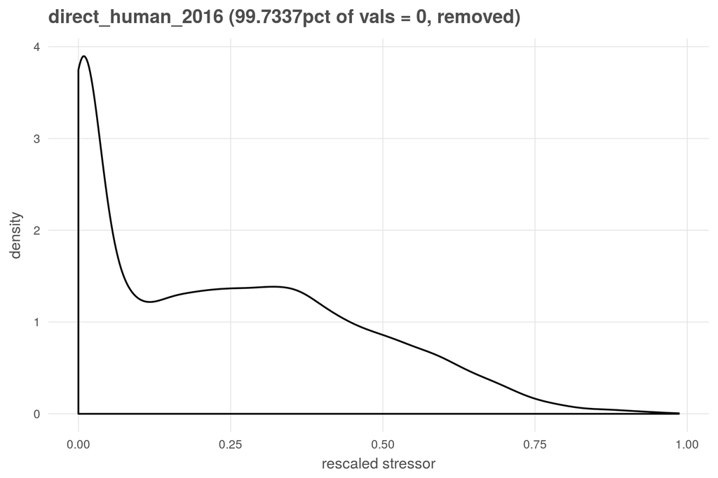

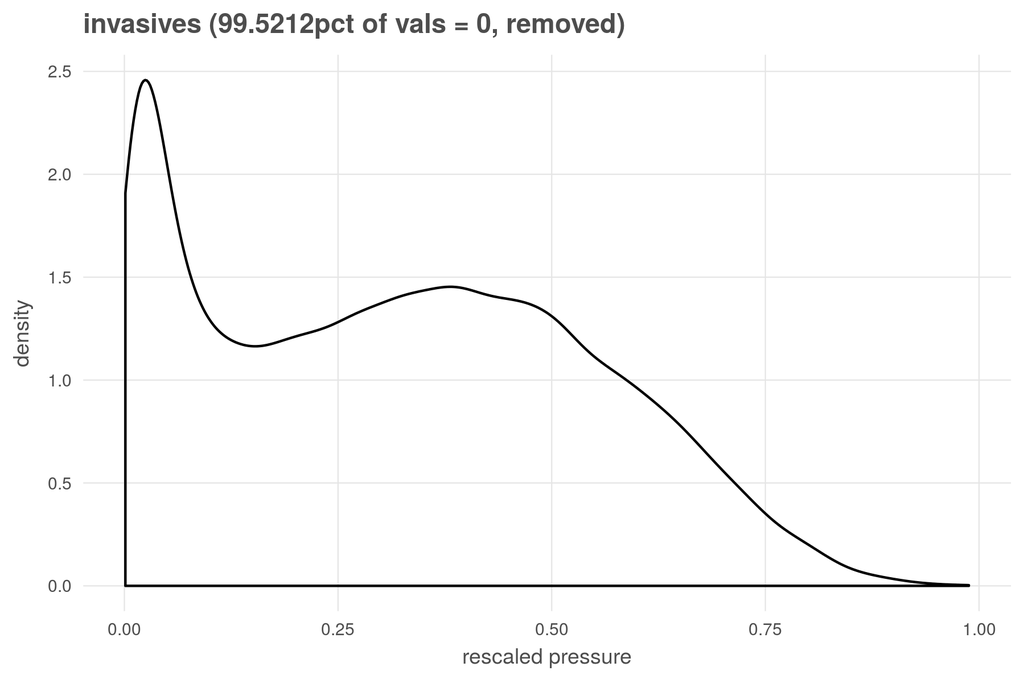

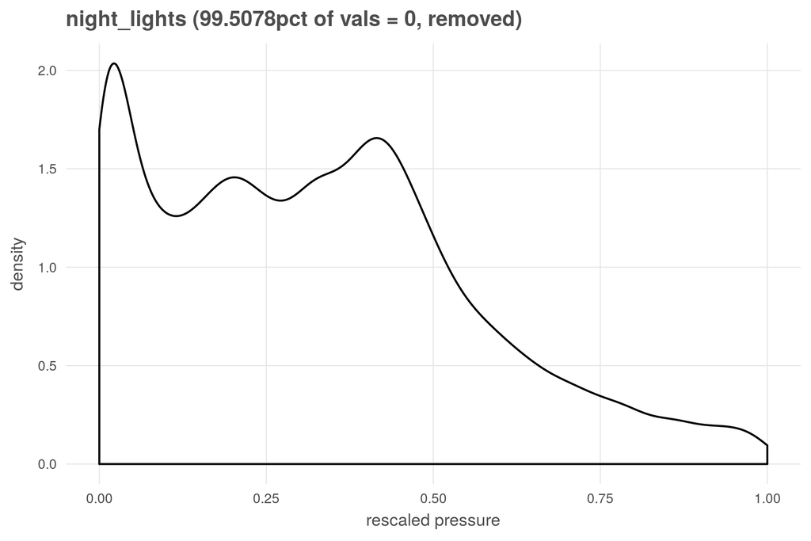

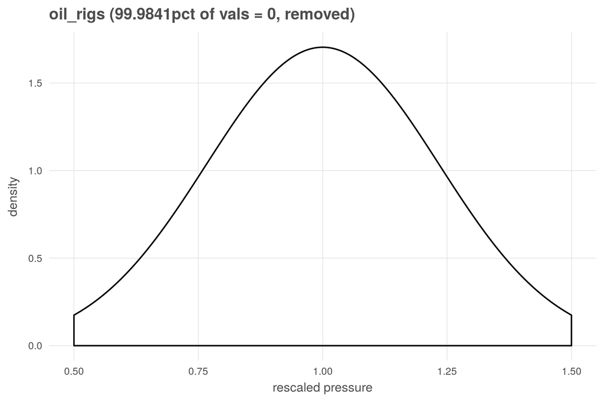

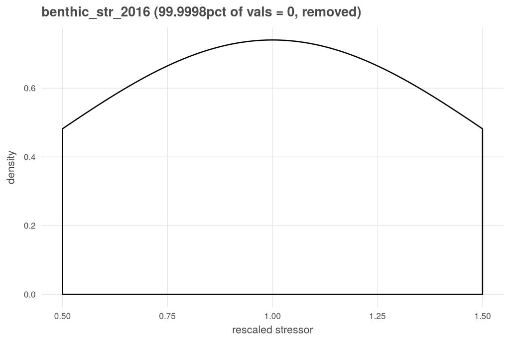

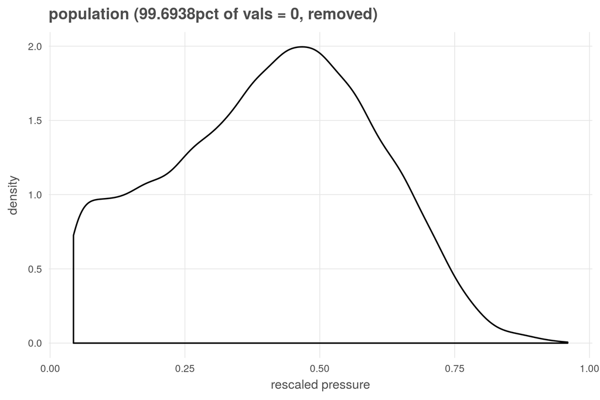

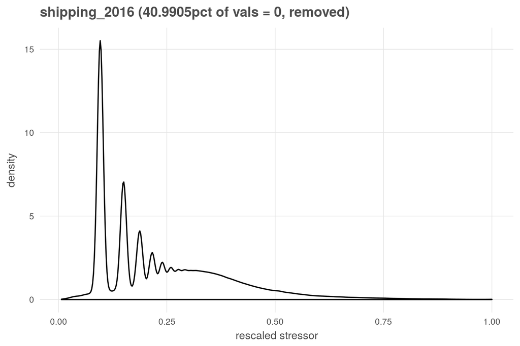

## 3.3 Create simple aggregated stressors layers

For each stressor layer at Mollweide 934m projection:

- create a dataframe of LOICZID values and stressor values
- summarize mean, variance, and number of cells to LOICZID cells after clipping out NA values.

```r
stressor_layers <- list.files(dir_stressor_anx,
                         pattern = '.tif$',
                         full.names = TRUE)

for (layer in stressor_layers[c(8, 18, 19)]) { ### layer <- stressor_layers[15]
  lyr_rast_raw <- raster(layer)

  print(summary(lyr_rast_raw))

}
```

```r
stressor_layers <- list.files(dir_stressor_anx,
                         pattern = '.tif$',
                         full.names = TRUE)

for (layer in stressor_layers) { ### layer <- stressor_layers[15]
  lyr_rast_raw <- raster(layer)

  lyr_name <- names(lyr_rast_raw)

  lyr_simple_file <- file.path(dir_git, sprintf('stressor_to_loiczid/%s_simple.csv', lyr_name))

  if(!file.exists(lyr_simple_file)) {

    if(!exists('vals_loiczid_moll')) {
      message('Initializing vals_loiczid_moll vector...')
      loiczid_moll_rast <- raster(file.path(dir_o_anx, 'spatial', 'loiczid_moll_934m.tif'))
      vals_loiczid_moll <- values(loiczid_moll_rast)
    }

    message('generating simple stressor summary to LOICZID for: ', lyr_name)
    message('... masking raw stressor layer to ocean base')
    lyr_rast <- mask(lyr_rast_raw, ocean_base, progress = 'text')

    message('... converting values to dataframe')
    lyr_df <- data.frame(loiczid = vals_loiczid_moll,
                         stressor_val = values(lyr_rast))

    message('... summarizing data frame')
    lyr_summary_df <- lyr_df %>%
      filter(!is.na(loiczid)) %>%
      group_by(loiczid) %>%
      summarize(stressor_mean = mean(stressor_val, na.rm = TRUE),
                stressor_var  = var (stressor_val, na.rm = TRUE),
                n_zero   = sum(stressor_val == 0, na.rm = TRUE),
                n_na     = sum(is.na(stressor_val))) %>%
      mutate(loiczid = as.double(loiczid))

    write_csv(lyr_summary_df, lyr_simple_file)

  } else {
    message('simple stressor summary already exists for: ',
            lyr_name, '\n  ', lyr_simple_file)
  }
}
# prov_wrapup(commit_outputs = FALSE)
```